# MA213 - Fall 2025

# Basic Statistics and Probability

## **Lab Session 4: Simulation and probability**

In this lab session, we will go over central limit theorem. Can we verify central limit theorem by simulation?

## Pre-lab activities

- The role of sampling distribution : Why do we care about sampling distribution?
  1. What is sampling distribution?

  -> In inferential statistics, we estimate the characteristics of the population parameter by using characteristics of sample (statistic).

  -> The distribution of the statistic obtained from sample is called sampling distribution.

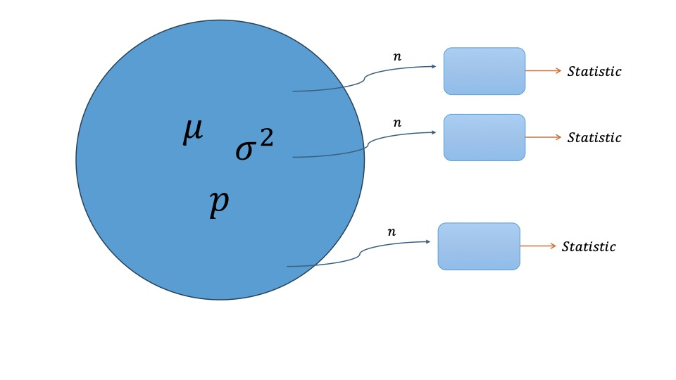

## Lab activities

We have a hypothetical population that are

```r
pop <- c(rep("Apple", 10), rep("Android", 4))
```

So that the true proportion of having apple device is $p=\frac{10}{14}$.

1. Let’s sample them and assign it to an object `p_hat` .

   (hint : use `sample()` and how many are there are apple ?)

```r
pop <- c(rep("Apple", 10), rep("Android", 4))
n = 3
my_sample <- sample(pop, n)
p_hat <- sum(my_sample == "Apple") / n
p_hat
```

```
## [1] 0.3333333
```

2. What is the sampling distribution look like? (obtain a vector `p_hat`)

   (hint : Use `for loop` )

```r
K = 100
p_hat <-rep(0,K)

for (k in 1:K){
  my_sample <- sample(pop, n)
  p_hat[k] <- sum(my_sample == "Apple") / n
}
p_hat
```

```
##   [1] 0.6666667 1.0000000 0.6666667 1.0000000 0.6666667 1.0000000 1.0000000
##   [8] 0.6666667 0.3333333 0.6666667 1.0000000 0.6666667 0.6666667 1.0000000
##  [15] 0.6666667 1.0000000 1.0000000 0.6666667 1.0000000 1.0000000 0.6666667
##  [22] 0.6666667 0.6666667 0.6666667 0.6666667 0.6666667 0.3333333 1.0000000
##  [29] 0.3333333 0.6666667 0.6666667 0.6666667 0.6666667 0.6666667 1.0000000
##  [36] 0.6666667 0.3333333 0.6666667 0.6666667 1.0000000 0.6666667 0.3333333
##  [43] 0.6666667 0.6666667 0.0000000 0.6666667 0.3333333 0.6666667 0.3333333
##  [50] 0.6666667 0.3333333 0.0000000 0.6666667 1.0000000 0.6666667 0.6666667
##  [57] 0.6666667 0.6666667 1.0000000 0.6666667 0.6666667 1.0000000 0.6666667
##  [64] 0.6666667 1.0000000 1.0000000 0.6666667 0.3333333 0.6666667 0.6666667
##  [71] 0.3333333 0.0000000 0.6666667 1.0000000 0.3333333 0.6666667 0.6666667
##  [78] 0.6666667 1.0000000 1.0000000 0.6666667 1.0000000 0.6666667 0.3333333
##  [85] 0.6666667 1.0000000 0.6666667 0.6666667 1.0000000 0.6666667 0.6666667
##  [92] 0.6666667 0.6666667 0.6666667 0.6666667 0.6666667 0.6666667 0.6666667
##  [99] 0.6666667 0.3333333
```

3. Using `p_hat` vector, show sampling distribution of the statistic.

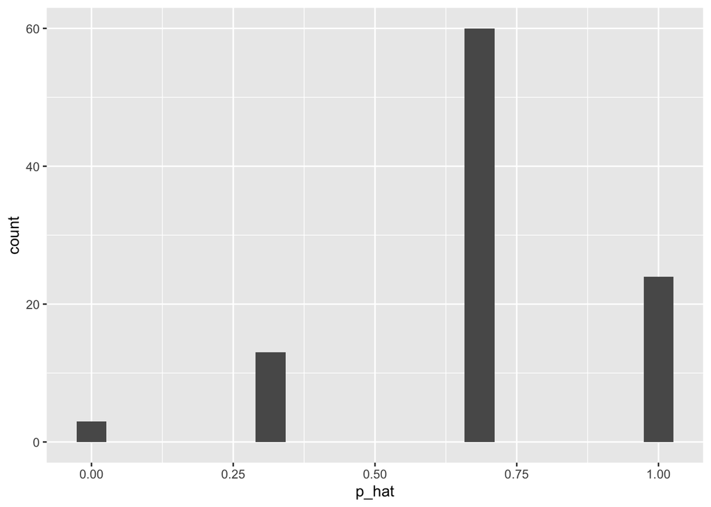

```r
sample_data <- data.frame(p_hat = p_hat)

ggplot(data=sample_data, aes(x=p_hat)) + geom_histogram(bins=20)
```

4. Now you are given much bigger hypothetical population where

   ```r
   pop <- c(rep("Apple", 1000), rep("Android", 400))
   ```

   Now you know that the true population proportion is $p=0.7142$ .

   Let’s make a function `my_sample` to give shape of distribution. (input `n`, output vector `p_hat`).

   ```r
   pop <- c(rep("Apple", 1000), rep("Android", 400))

   n = 100
   K = 1000
   p_hat <-rep(0,K)

   for (k in 1:K){
     my_sample <- sample(pop, n)
     p_hat[k] <- sum(my_sample == "Apple") / n
   }
   head(p_hat)
   ```

   ```
   ## [1] 0.71 0.72 0.66 0.72 0.73 0.68
   ```

   ```r
   my_sample <- function(n){
   K = 1000
   p_hat <-rep(0,K)

   for (k in 1:K){
     my_sample <- sample(pop, n)
     p_hat[k] <- sum(my_sample == "Apple") / n
   }
   p_hat

   }

   head(my_sample(10))
   ```

   ```
   ## [1] 0.9 0.9 0.8 0.6 0.5 0.7
   ```

   ```r
   head(my_sample(100))
   ```

   ```
   ## [1] 0.77 0.72 0.71 0.73 0.65 0.79
   ```

5. Using `my_sample` function, show the sampling distribution of the statistic. Change `n` from 10 to 100. What do you conclude?

```r
library(dplyr)
p_hat = my_sample(1000)

p_hat_data <- data.frame(p_hat = p_hat)


p_hat_data <- p_hat_data %>%
  count(p_hat) %>%
  mutate(pdf = n/sum(n))


mean(p_hat_data$p_hat)
```

```
## [1] 0.7148667
```

```r
sd(p_hat_data$p_hat)
```

```
## [1] 0.01378669
```

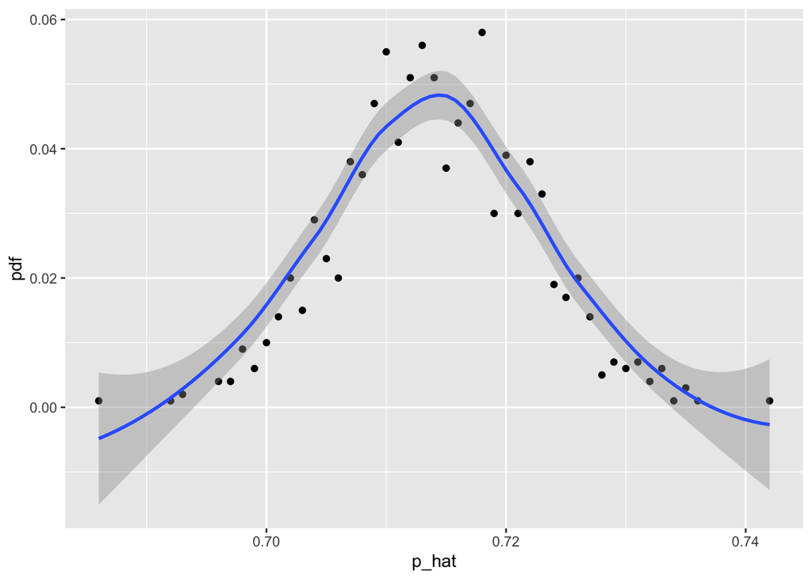

```r
ggplot(p_hat_data, aes(x=p_hat, y=pdf)) + geom_point() + geom_smooth()
```

### Post-lab activities

Recent statistics suggest that 10% of Americans rely on Social Network Sites (SNSs). We are going to have a simulation study if we can verify that CLT really works in this case too. Let’s assume that US population is 300,000 for calculation purposes.

Please name your submission as `lab4.R`

0. execute this `set.seed(213)`
1. Produce population data and assign it `population` object.
2. Obtain mean and standard deviation of the population and assign them to `mean_pop` and `sd_pop` accordingly.
3. Get the sample mean data for $n=10$ with $k=100$ iterations. Assign the mean and standard deviation of the sample mean data to `mean_sample` and `sd_sample`.
4. Do one more time with the sample mean data for $n=50$ with $k=100$ iterations. Assign the mean and standard deviation of the sample mean data to `mean_sample2` and `sd_sample2`.
5. (Extra)

   5.1) Show the shape of the sample proportion with n=10, k=1000.

   5.2) Show the shape of the sample proportion with n=1000, k=1000.